# Summary of Student Responses to the Introduction to Peer Reviewing Assignment

# Consistency

## Questions

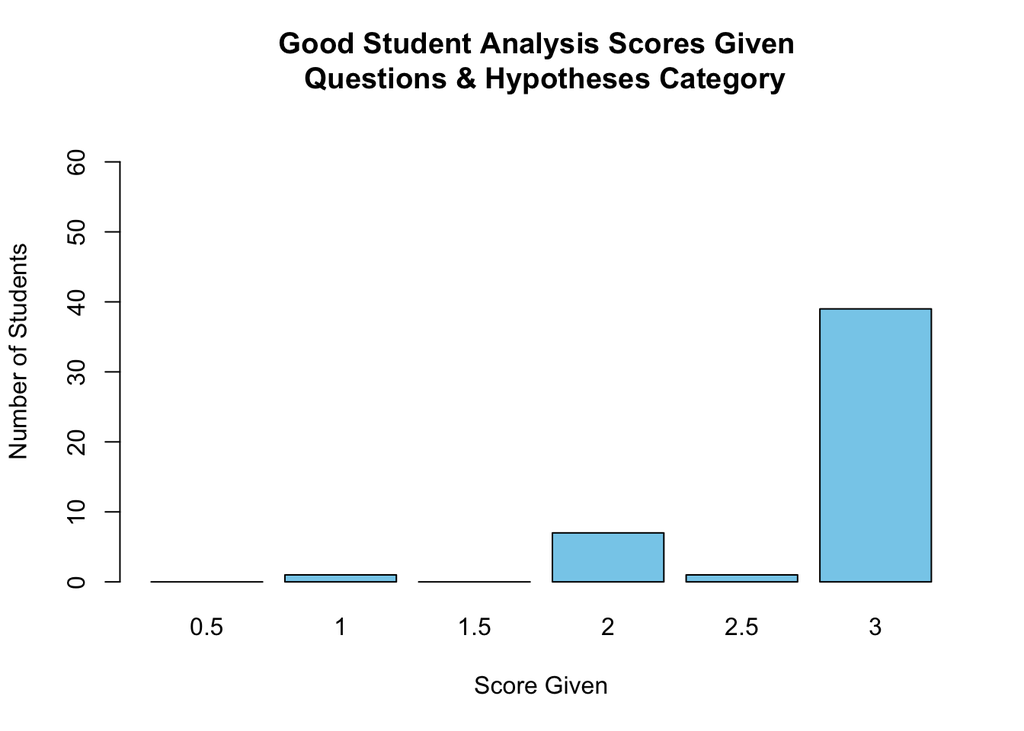

```r
barplot(table(factor(introcrit$Q2_1, levels=seq(0.5,3, .5))), main="Good Student Analysis Scores Given \n Questions & Hypotheses Category", ylim = c(0,66), xlab="Score Given", ylab="Number of Students", col="skyblue")
```

## Analysis

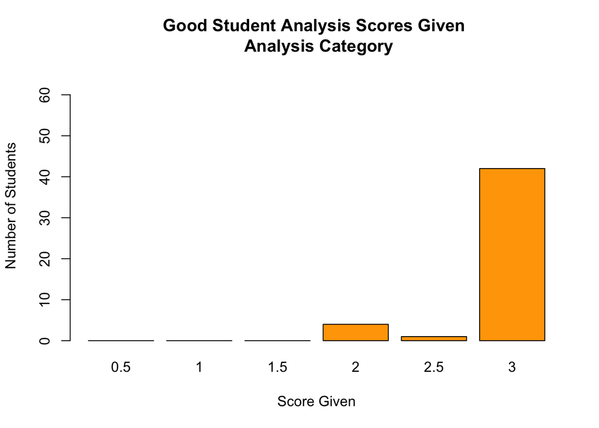

```r
barplot(table(factor(introcrit$Q2_2, levels=seq(0.5,3, .5))), main="Good Student Analysis Scores Given \n Analysis Category", ylim = c(0,66), xlab="Score Given", ylab="Number of Students", col="orange")
```

## Graphic

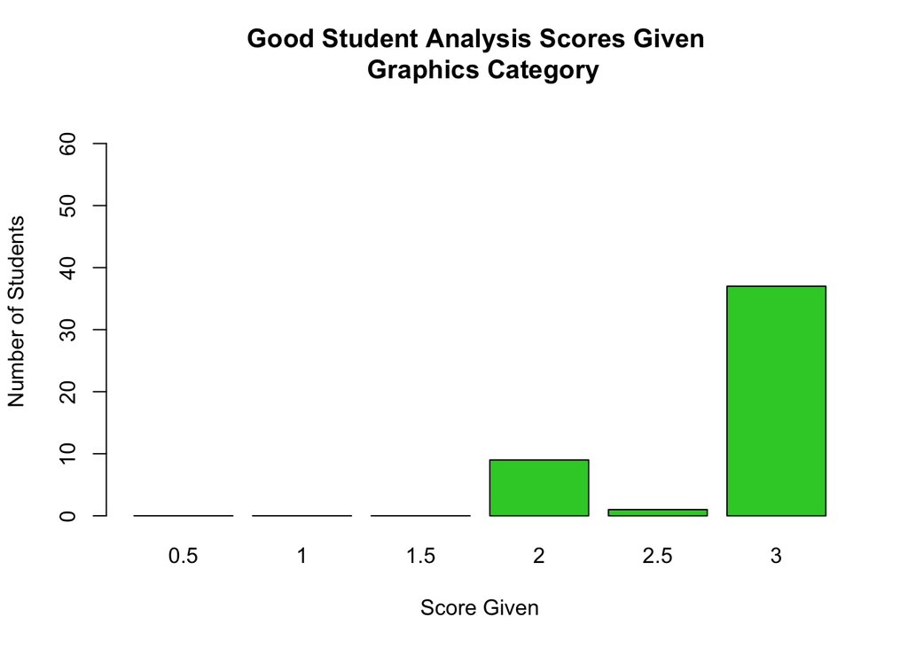

```r
barplot(table(factor(introcrit$Q2_3, levels=seq(0.5,3, .5))), main="Good Student Analysis Scores Given \n Graphics Category", ylim = c(0,66), xlab="Score Given", ylab="Number of Students", col="limegreen")
```

## Interpretation

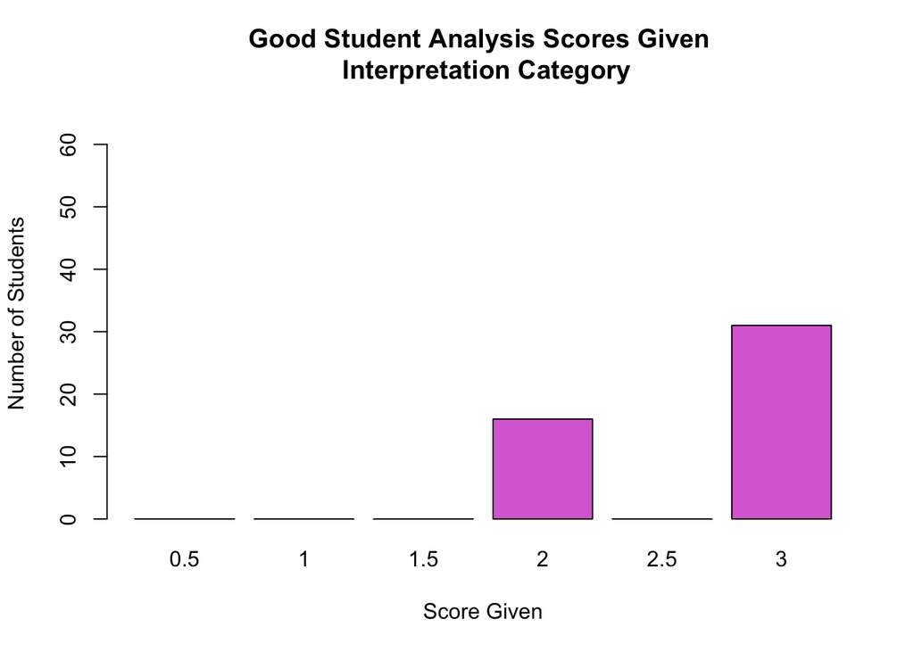

```r
barplot(table(factor(introcrit$Q2_4, levels=seq(0.5,3, .5))), main="Good Student Analysis Scores Given \n Interpretation Category", ylim = c(0,66), xlab="Score Given", ylab="Number of Students", col="orchid")
```

## Presentation

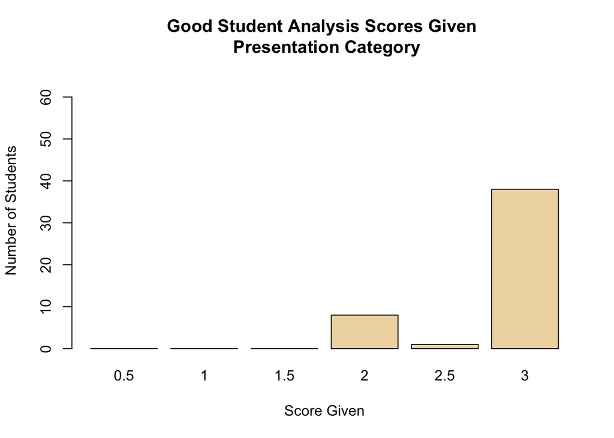

```r
barplot(table(factor(introcrit$Q2_5, levels=seq(0.5,3, .5))), main="Good Student Analysis Scores Given \n Presentation Category", ylim = c(0,66), xlab="Score Given", ylab="Number of Students", col="wheat2")
```

## Overall

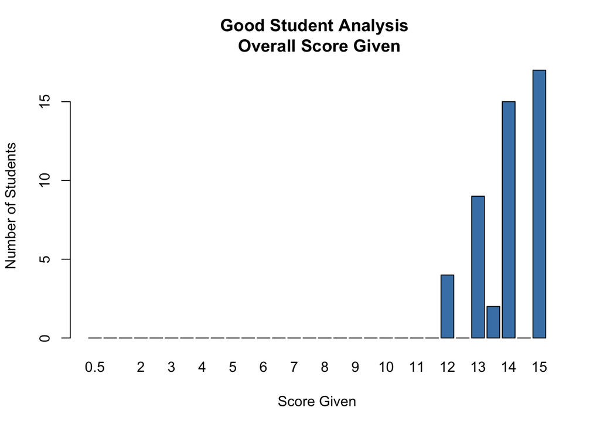

```r
introcrit$Overall1 <- sapply(1:nrow(introcrit), function(i) sum(introcrit[i,c("Q2_1", "Q2_2", "Q2_3", "Q2_4", "Q2_5")]))
barplot(table(factor(introcrit$Overall1, levels=seq(0.5,15, .5))), main="Good Student Analysis \n Overall Score Given", xlab="Score Given", ylab="Number of Students", col="steelblue")
```

# Written Feedback

```r
for (i in 1:nrow(introcrit)){
 cat("Student ", i, "\n\n")
 cat("&nbsp;&nbsp;Questions & Hypotheses: {", introcrit$Q2_1[i],"} <br/>")
 cat("&nbsp;&nbsp;Data Analysis: {", introcrit$Q2_2[i],"} <br/>")
 cat("&nbsp;&nbsp;Graphical Summary: {", introcrit$Q2_3[i],"} <br/>")
 cat("&nbsp;&nbsp;Interpretation: {", introcrit$Q2_4[i],"} <br/>")
 cat("&nbsp;&nbsp;Presentation: {", introcrit$Q2_5[i],"} <br/><br/>")
 cat(gsub("[??]","",gsub("/"," ",paste(introcrit$WrittenFeedback[i]))),"\n\n\n\n")
 cat("<br/><hr/>\n\n")
}
```

Student 1

Questions & Hypotheses: { 3 }  
Data Analysis: { 3 }  
Graphical Summary: { 3 }  
Interpretation: { 3 }  
Presentation: { 2 }  
Your Analysis was very effective in showing the reader the prices of student housing and can be considered very useful in determining which complex would be most beneficial financially. To make your analysis stronger, I would recommend taking a greater look at your sentence structure in the “Background” section. For instance, adding a comma behind BYU-Idaho in the first sentence and rephrasing sentences can create a stronger argument for the reader. However, Overall, your analysis was well thought out. It was very beneficial for me to see the results clearly through the color coded graphs. By making the graph colors the same color, it would make it more cohesive.

Student 2

Questions & Hypotheses: { 3 }  
Data Analysis: { 3 }  
Graphical Summary: { 3 }  
Interpretation: { 2 }  
Presentation: { 3 }  
I really liked your presentation and Data Analysis. One thing that might be helpful is in the interpretation to include BYUI student’s entry-level rent options instead of just NA. If the data isn’t available I would probably just leave it out. That’s personally what I would do but everything else in the interpretation looks very good.

I really liked how your graphic Analysis was clean and presented with good colors. The light blue and the dark blue make a great contrast which allows the reader to really understand the differences in princes occurring. It can be seen that a lot of time and effort was put into the design of this Analysis. Excellent work.

Student 3

Questions & Hypotheses: { 2 }  
Data Analysis: { 3 }  
Graphical Summary: { 3 }  
Interpretation: { 2 }  
Presentation: { 3 }  
Suggestion for improvement: I love how you’ve bolded numbers so they are easier to see. In the interpretation however, one number is coming up as NA (I believe it should be “single BYU-Idaho students entry level rent options average around$256.55a month.” )

Compliment: Your images were easy to understand, I appreciated how they started with one that focused on individual locations, and built up to a more general overview. You eased any concerns someone may have had about finding a place to live near campus with your comment “..there are apartments in all price ranges that are close to campus”.

Student 4

Questions & Hypotheses: { 3 }  
Data Analysis: { 3 }  
Graphical Summary: { 3 }  
Interpretation: { 2 }  
Presentation: { 3 }  
While I was reading your interpretation I noticed where it’s supposed to state what the average entry level rent is, it shows up as $NA. I would check your coding and make sure that you’re not missing any commas, periods, or anything like that. I thought your graphics were really nice and easy to understand. I think all your graphics follow the stand alone rule. I like what you chose to do with your bar graph by coloring the 2 bars slightly different shades of blue making it easier for the viewer to interpret the graph.

Student 5

Questions & Hypotheses: { 3 }  
Data Analysis: { 3 }  
Graphical Summary: { 3 }  
Interpretation: { 3 }  
Presentation: { 3 }  
I love they way that this is laid out your analysis with the graph and then an explanation that talked about specific parts of the graph in the last section. However I feel like you could improve by adding more of those details in the middle as well instead of keeping it till the end, for instance when dealing with location from campus and cost of rent.

Student 6

Questions & Hypotheses: { 3 }  
Data Analysis: { 3 }  
Graphical Summary: { 3 }  
Interpretation: { 3 }  
Presentation: { 2 }  
I really enjoyed the graph with the housing distance from the MC and the cost to be very interesting and very helpful for students to find a happy medium between the two. I feel as though the titles for each section such as background and analysis should have been more consistent in size but that is mainly a preference of mine. Also on the first graph, I get why the two first things were dark blue, I just don’t them really necessary personally. Many great explanations and it is very useful information.

Student 7

Questions & Hypotheses: { 3 }  
Data Analysis: { 2 }  
Graphical Summary: { 3 }  
Interpretation: { 3 }  
Presentation: { 3 }  
Your Analysis was very well executed! Excellent in the way it caught my attention and how well all the points flowed, in other words, I wasn’t lost in reading from paragraph to paragraph.

One thing I would advise is to make your data analysis less wordy in general. Its hard because im being nit picky but allow for some extra time else where considering your graphs do a great job at telling your data to the reader.

Student 8

Questions & Hypotheses: { 3 }  
Data Analysis: { 3 }  
Graphical Summary: { 3 }  
Interpretation: { 3 }  
Presentation: { 3 }  
Excellent job on your “Student Housing Costs” Presentation! I enjoyed how clean-cut you made it look and feel to navigate it. The flow of the information seemed very clean up until the very last bit when you talked about your “Interpretation”. I feel that you could spice up the presentation of that part to make it match the outstanding work you’ve done with the rest of the document by simply matching the size of the font to the rest of the documented information and adding some color to the text over the money costs to make them stand out. Even with that, excellent job! I am fully impressed.

Student 9

Questions & Hypotheses: { 3 }  
Data Analysis: { 3 }  
Graphical Summary: { 3 }  
Interpretation: { 3 }  
Presentation: { 3 }  
This analysis looks spectacular. One tinny part that I would suggest is making sure that you label your bar graph with the colors. It took me a second to figure out what it was saying. I really enjoyed how interactive you were able to make everything. It really pulled me in and made it really interesting. Again I think you did a great job.

Student 10

Questions & Hypotheses: { 3 }  
Data Analysis: { 3 }  
Graphical Summary: { 2.5 }  
Interpretation: { 2 }  
Presentation: { 3 }  
Your histogram could be improved by labeling the y-axis to help it better meet the stand alone principle.

Well done with your scatterplot. The detailed scatterplot with colors and labels for each specific point on the scatterplot makes it look more impressive.

Student 11

Questions & Hypotheses: { 3 }  
Data Analysis: { 5 }  
Graphical Summary: { 4 }  
Interpretation: { 4 }  
Presentation: { 4 }  
The analyses had very strong data and was clear that student knew what they were doing. The graph was very clear to read and interpret. However, I wish the student would have followed the same color scheme that they used for the other bars. I also really liked the summary provided below the graph, which help me gain insight on what the message was that was being delivered. One thing that I did not like as much was the font choice on the dollar amounts. I would have liked to see the font be unified for the entire analyses. Overall, I would give this assignment a 4 5 stars! Great job!

Student 12

Questions & Hypotheses: { 3 }  
Data Analysis: { 3 }  
Graphical Summary: { 3 }  
Interpretation: { 2 }  
Presentation: { 3 }  
I really liked how in your Analysis you didn’t just show us a graph, which was well labeled and colored, but you also broke it down and showed us the min, median, mode, and so on. I also liked how you had given us multiple graphs to look at and compare to each other . As well as putting in graphs I like how you interpreted each one and explained what the findings meant.

I would suggest to maybe beefing up your interpretation a little more by summarizing all your findings from your analysis and not just one part, being, if the housing is reasonably priced. My other advice would be that you are trying to determine if BYUI housing is fairly priced in your conclusion by comparing it to the average expenditure of renters but you don’t say if that is the average for the U.S. or for Idaho which can make a huge difference. For example if it’s compared to the whole U.S. then it’s going to be skewed because of expensive big cities and more expensive states.

Student 13

Questions & Hypotheses: { 3 }  
Data Analysis: { 3 }  
Graphical Summary: { 3 }  
Interpretation: { 3 }  
Presentation: { 3 }  
This looks really good! I like how additional information can be found out about each housing unit by pressing the green button that is really useful. You do a good job explaining and answering your questions. On your price versus distance from the Manwaring graph, you might want to consider picking more contrasting colors for the male and female dots. The two colors you picked are very similar and it can be difficult to differentiate between them.

Student 14

Questions & Hypotheses: { 2 }  
Data Analysis: { 3 }  
Graphical Summary: { 3 }  
Interpretation: { 3 }  
Presentation: { 3 }  
Your analysis could explain a bit more about what the “frequency” axis means in your graph. This way, we have something to compare the prices to. Is it the frequency of full apartments or the frequency of returning to the same apartment after one semester

Good job on your interactive housing graphic, I really like how detailed the scatterplot is in specifying specific distance to the Manwaring Center and price for each apartment.

Student 15

Questions & Hypotheses: { 3 }  
Data Analysis: { 3 }  
Graphical Summary: { 3 }  
Interpretation: { 2 }  
Presentation: { 3 }  
I think you might want to mention the relationship between distance and price in your interpretation because you had an entire graphic devoted to that.

I really enjoyed the interactive graphic you had that was about the relationship between distance and price because of the ability to hover over the points and see the apartment name, longitude, and latitude.

Student 16

Questions & Hypotheses: { 2.5 }  
Data Analysis: { 2.5 }  
Graphical Summary: { 3 }  
Interpretation: { 3 }  
Presentation: { 2.5 }  
Very good job on the interpretation section of your analysis. You showed very good attention to detail in listing all the important aspects of your analysis. However, you struggled to use strong language to describe how your analysis totally benefits the person reading the review. i suggest revising the conclusion of that paragraph to strengthen your analysis. Great job on the grammar and strong working n the analysis. You showed great detail in using such strong language throughout your analysis.

Student 17

Questions & Hypotheses: { 3 }  
Data Analysis: { 2 }  
Graphical Summary: { 3 }  
Interpretation: { 3 }  
Presentation: { 3 }  
Great job on the graphs. The graphical summaries were very detailed and well said. One thing that I noticed is that your data analysis could be a little stronger by adding a little more detailed. Otherwise, everything was portrayed well.

Student 18

Questions & Hypotheses: { 3 }  
Data Analysis: { 3 }  
Graphical Summary: { 2 }  
Interpretation: { 3 }  
Presentation: { 3 }  
I really liked your presentation because it was easy to look at and flowed nicely. The graphs were interesting and colorful and made it easy to see what you were talking about. I also enjoyed how you introduced the project because it immediately caught my attention. I wish I could have seen how many housing options were in the price ranges on you bar graph, so that it could be fully read without an explanation, but other than that, I really loved it all!

Student 19

Questions & Hypotheses: { 2 }  
Data Analysis: { 3 }  
Graphical Summary: { 2 }  
Interpretation: { 3 }  
Presentation: { 2 }  
Suggestion:

It might be useful to clarify what your hypothesis is in the beginning. I am guessing it had to do with the assumption that people are looking for housing, but making that clear might be good. On the second graph, the colors are hard to see on my computer screen, I’d suggest making them with a little more contrast.

Compliment:

Very well written, with useful information and applicable application for students. I appreciate the simplicity of it and the ability to search for what is needed. Great job.

Student 20

Questions & Hypotheses: { 3 }  
Data Analysis: { 3 }  
Graphical Summary: { 3 }  
Interpretation: { 3 }  
Presentation: { 3 }  
Good work on your analysis. I love how interactive it is. Being able to go through information of each apartment if desired is very nice. I also think it is great that you have links to where you found your information. This interactive analysis not only shows what you have found through your research, but allows the viewer to continue researching for themselves if desired.

This could be a little knit picky, but there are a few sentences that could be revised to flow a little easier for the reader. One section used the word “however” multiple times. I think that taking out the first “however” would make the two sentences less awkward. For example: “As shown in the plot below(remove however), it does not appear…”. Keeping “however” in the second sentence is just fine.

Again, wonderful work!

Student 21

Questions & Hypotheses: { 3 }  
Data Analysis: { 3 }  
Graphical Summary: { 2 }  
Interpretation: { 2 }  
Presentation: { 3 }  
On the interpretation, where you calculated the average rent per month, there’s a mistake. It shows $NA. instead of NA, you could put a real calculated number.

One thing I really liked was the “2018 BYU - Idaho Housing” graph. When I hover my mouse to each plot, it shows the name, distance, and the price. This made it so much easier to understand the graph and helped me to understand the data.

Student 22

Questions & Hypotheses: { 3 }  
Data Analysis: { 3 }  
Graphical Summary: { 3 }  
Interpretation: { 3 }  
Presentation: { 3 }  
I am grateful that in the first sentence of your analysis you mentioned that the data was the “full population of BYU-Idaho approved housing complexes”. However, I do recommend to write this in the background information. Doing so would have helped me know that we were looking at the population and not a sample early in your analysis. I was initially looking for a hypothesis until I read the sentence in your analysis.

I really enjoyed the interactive nature of your whole analysis. I enjoyed the ability to look at extra information for multiple housing options. It made me curious to know if there could be a correlation between the extra options and the amount of students that buy the contracts.

Student 23

Questions & Hypotheses: { 3 }  
Data Analysis: { 3 }  
Graphical Summary: { 3 }  
Interpretation: { 2 }  
Presentation: { 2 }  
The graphics are extremely helpful in showing prices of the housing complexes, being interactive helps a student discover even more information from your analysis.

There is a problem in the interpretation however, the average rent seems to have not been filled in. There is an NA in place of it.

Student 24

Questions & Hypotheses: { 3 }  
Data Analysis: { 3 }  
Graphical Summary: { 3 }  
Interpretation: { 3 }  
Presentation: { 3 }  
Suggestion

I would have liked to have seen some clarifying figures readily available, like when you said: “This plot shows a fair percentage of apartments have entry-level contracts ranging between $800and$1000 a semester. This is shown in the graphic above by the dark blue bars.” The histogram shows well the general range of prices, but the wordfairseems a bit too subjective and less scientific. To avoid this, I would suggest giving a ratio or percentage, perhaps within parentheses to specify the “fair” figure to which you are referring.

For example: “This plot shows a fair percentage (48%) of apartments have entry-level contracts ranging between $800and$1000a semester. This is shown in the graphic above by the dark blue bars.”

Compliment:

The clarity of displaying your price information with a histogram was well done and a good choice. It pairs well with the scatterplot graph of distance to the Maywaring Center on campus. With these two graphs, one can more easily see the relationship between price and distance from school. Good Job!

Student 25

Questions & Hypotheses: { 3 }  
Data Analysis: { 3 }  
Graphical Summary: { 3 }  
Interpretation: { 2 }  
Presentation: { 3 }  
The only critique I have is about the “NA” amount per month in your interpretation. Without that average represented value, it takes away from the confidence impact of your statement.

I like how the flow of analysis follows the order of the questions in the background. I also like the organization and universal color scheme.

Student 26

Questions & Hypotheses: { 3 }  
Data Analysis: { 3 }  
Graphical Summary: { 3 }  
Interpretation: { 3 }  
Presentation: { 3 }  
In your interpretation, you say “single BYU-Idaho students entry level rent options average around $NA a month”. I’m guessing you didn’t mean $NA so maybe check out why that’s showing up and correct it so we can see the actual figure.

I thought the scatter plot was very useful and it helped make your interpretation easy to understand and backed it up with easily understood data.

Student 27

Questions & Hypotheses: { 2 }  
Data Analysis: { 3 }  
Graphical Summary: { 2 }  
Interpretation: { 3 }  
Presentation: { 3 }  
Your background information was interesting and relatable to read; however, based on how you posed multiple hypothetical questions it made it difficult to see where exactly you were going with your analysis. You would be able to adjust this by having a sentence stating what you would be looking for exactly, instead of posing multiple questions.

Your scatter plot was incredibly interesting to look at and use. It was very helpful that you made it interactive in a way that just scrolling over the point told you it’s exact plot, but also for which apartment complex. This made the whole plot much easier to understand and utilize.

Student 28

Questions & Hypotheses: { 3 }  
Data Analysis: { 3 }  
Graphical Summary: { 3 }  
Interpretation: { 3 }  
Presentation: { 3 }  
You did a great job including a well written background in your analysis. It is impressive that you cited the source and provided instruction on how to use your dataset. In the background, you mentioned that there are many factors in making housing decisions. I think that begs the question of what those factors are. I would list the possible factors, not just the two main factors (we don’t even know if those two are major factors to the reader). But over all, you did a great job!

Student 29

Questions & Hypotheses: { 3 }  
Data Analysis: { 3 }  
Graphical Summary: { 3 }  
Interpretation: { 2 }  
Presentation: { 2 }  
I really liked that you thought to include a table that compares the high-end housing options with the regular room price. Your graphs all look beautiful and well labled. It’s obvious you’ve put a lot of effort into this analysis.

I would suggest increasing the header size for the section title “Interpretation” so it matches the other section titles. This could be done by adding # signs to the beginning of the line so that it matches with the previous ones.

In the first paragraph of that same section, there seems to be a problem with your last inline code. Instead of giving the desired average, it’s showing an NA result. I can’t see the code for this, so I have no idea how to suggest a fix.

Student 30

Questions & Hypotheses: { 3 }  
Data Analysis: { 3 }  
Graphical Summary: { 3 }  
Interpretation: { 2 }  
Presentation: { 3 }  
In the interpretation section at the bottom of the first paragraph, the average amount per month isn’t coming through. One other suggestion to consider is using bold for the dollar amounts used in your analysis and interpretation instead of the larger font size.

Other than those two things, great work on the presentation and the all of your graphics. I like the order in which you present your analysis, its very intuitive.

Student 31

Questions & Hypotheses: { 3 }  
Data Analysis: { 3 }  
Graphical Summary: { 3 }  
Interpretation: { 3 }  
Presentation: { 3 }  
I believe your interpretation of overall housing costs of student housing in rexburg compared to national data was very helpful, however in the dollar amount listed for monthly costs for entry level rent options is listed as “$NA” I’m sure this is an easy fix and it isn’t too hard to do the calculation on my own because your other data is clear, but your analysis would benefit from showing complete data

The analysis of housing costs relative to distance from campus was very helpful because it showed that there was no correlation between cost and relative distance to campus. that would be a useful tool for any student looking to make a housing decision. this would allow the student to consider other factors when making the decision on where to live.

Student 32

Questions & Hypotheses: { 3 }  
Data Analysis: { 3 }  
Graphical Summary: { 3 }  
Interpretation: { 3 }  
Presentation: { 3 }  
I thought the interactive scatterplot was very useful. One suggestion I do have to consider other buildings on campus to measure the housing distance from. This would help out students who spend most of their time on the upper part of campus, for example, because they would not have to walk all the way up the hill if they choose an apartment building closer to the top.

Great job on the interpretation! Thanks to you, I now understand how BYUI housing compares to the rest of the world.

Student 33

Questions & Hypotheses: { 3 }  
Data Analysis: { 3 }  
Graphical Summary: { 3 }  
Interpretation: { 3 }  
Presentation: { 3 }  
You had some spelling errors. For example, I believe you meant, “Bureau of labor statistics.” I am so impressed with your attention to detail. A great example is the note that you made after the interpretation. It gave some great disclaimers and clarification.

Student 34

Questions & Hypotheses: { 3 }  
Data Analysis: { 3 }  
Graphical Summary: { 3 }  
Interpretation: { 3 }  
Presentation: { 3 }  
I do not see much of a point in including the statistic from the Burea of Labor Statistics except to help emphasize how lucky we are to have much cheaper rent than most others. Also when saying what the average single BYUI students rent average, you forgot to include the number, so it says “$ N A”.

I really enjoyed the background given from your analysis. I really liked how the first two sentences really piques the readers interest for the analysis you gave. I also enjoyed the spacing you gave for the background, it helped give the switch from introduction to questions to how the data was collected.

Student 35

Questions & Hypotheses: { 3 }  
Data Analysis: { 3 }  
Graphical Summary: { 2 }  
Interpretation: { 3 }  
Presentation: { 3 }  
Overall you did a great job! One thing I wonder is your absence of ‘Distance to Campus’ section similar to your ‘Price’ section. I think that it wouldn’t hurt to have the 5 Number Summary of distances. That way you can give your audience a better picture of what the distances to campus usually are.

I think that your scatterplot does an excellent job of giving your audience their options right away. By hovering the cursor over the points, you make it easier to look up prices without having to compare within a table like at the beginning of your analysis.

Student 36

Questions & Hypotheses: { 3 }  
Data Analysis: { 3 }  
Graphical Summary: { 3 }  
Interpretation: { 3 }  
Presentation: { 3 }  
Great work on your analysis, I especially liked how you addressed other factors that could have had an impact on your results. I also really liked how one of your graphs was split between male and female housing, as that is an important contributing factor to the cost of housing here in Rexburg.

Maybe next time you could include a few more columns of important characteristics, for example, “quality of living” or “number of tenants per room.” This would help to give a more accurate analysis of the housing cost situation in Rexburg.

Student 37

Questions & Hypotheses: { 3 }  
Data Analysis: { 3 }  
Graphical Summary: { 2 }  
Interpretation: { 2 }  
Presentation: { 3 }  
Great job on your graphics and their descriptions. It was nice reading your descriptions and seeing how they matched up with your graph. I also really liked how you used 2 different colors in the bar graph and in the scatter plot. This made it easy for me to make my own conclusions and to visualize yours. Having a little key off to the side of the 1st graphic, like you do in the 3rd one, would be beneficial I think, but you did an excellent job explaining the graphics in your descriptions. Overall, well done!

Student 38

Questions & Hypotheses: { 3 }  
Data Analysis: { 3 }  
Graphical Summary: { 2 }  
Interpretation: { 2 }  
Presentation: { 3 }  
Questions and Hypothesis:

Your questions were concise and stated in the beginning which is great! I liked that because it allowed the reader to follow the rest of your analysis easily because they knew what to expect.

Data Analysis:

This was also really well done. It followed the same structure of answering your questions in the same order that they were asked. One thing that I would change potentially is that the limitations that you put in your interpretation I would move to the beginning of your data analysis. This is only a stylistic change so you don’t really have to.

Graphical Summaries:

I loved your graphics! I thought the interactive parts of your data made it easy to see what was going on and allowed it to be interesting and so you can understand it at a glance but still have access to more details. I would say that for the histogram I would label where the 5 number summary values occur. This allows the reader to understand the distribution even better. As you stated “half of prices are above $1120”. I think it would be cool to see that.

For your stacked dot plot I would suggest putting the units in your x-axis. I know it’s nit picky but it’s nice to have.

I would consider changing the data table you have in your background section to include the walking distance in the main part of the table rather in the more detailed part. I say this because your second thesis is “are apartments close to campus more expensive” as such it should be on the front and addressed in more detail because that’s what you’re trying to see.

Interpretation

I thought your interpretation was good. I liked how you compared the labor statistics to your data set. This puts the price of apartments in Rexburg into perspective compared to the rest of the nation. I noticed a little error where it says “single BYU-Idaho students entry level rent options average around$NA$NAa month” The $NA part is probably from a bug in the code. Because it’s your interpretation it might just be easier to type it rather than reference it (if that’s what you’re doing in your code).

Student 39

Questions & Hypotheses: { 2 }  
Data Analysis: { 3 }  
Graphical Summary: { 3 }  
Interpretation: { 2 }  
Presentation: { 3 }  
Your graphics and analysis where both very good. One thing that I think could be improved is the framing of the question that you were researching. You write, “So just how much does student housing in Rexburg cost And are apartments close to campus more expensive These are just a few possible questions one could ask as they look for housing in Rexburg.”

It was not immediately obvious to me that these were the questions that you were researching because you say that they are examples of questions that one might have, not that they are the questions that you were investigating. This confused me as to what the question that you were researching was until I had read the interpretation portion.

Other than this somewhat minor complaint, good job! It answers the question and looks good.

Student 40

Questions & Hypotheses: { 3 }  
Data Analysis: { 3 }  
Graphical Summary: { 3 }  
Interpretation: { 3 }  
Presentation: { 3 }  
It was a really good analysis. my suggestion would be adding a box plot to help the reader see a virtual picture of the summary

Nice work on the graphic, I really like how you use different colors to represent different things. I also like that you start off the analysis with a background story of the topic.

Student 41

Questions & Hypotheses: { 3 }  
Data Analysis: { 3 }  
Graphical Summary: { 3 }  
Interpretation: { 3 }  
Presentation: { 3 }  
Everything in the analysis is great but it would nice to have a heat legend for the histogram so we know if the light blue is high in volume or the dark blue is high. I really enjoyed looking through all the apartments and seeing all the data on each complex. Also, the scatter plot was great to hover over and see the labeling if it was men or women housing. Great job overall just a simple touch up on the histogram.

Student 42

Questions & Hypotheses: { 3 }  
Data Analysis: { 3 }  
Graphical Summary: { 3 }  
Interpretation: { 3 }  
Presentation: { 3 }  
Everything in this example looked really good. The only thing I could think of is maybe adding a key to the “BYU-Idaho Housing One Semester Entry Level Contract Prices” graph. It is listed what dark blue means in the text, but a quick key to the side of the graph could portray the data more efficiently.

I really love the scatter plot at the bottom of the report. One thing I specifically love is how it is interactive. It was fun to find my apartment and those of my friends. It was also interesting to see that there was no correlation in distance from campus in price.

Student 43

Questions & Hypotheses: { 2 }  
Data Analysis: { 3 }  
Graphical Summary: { 3 }  
Interpretation: { 3 }  
Presentation: { 3 }  
I think both of your questions could be worded differently to be more concise. As they are currently standing, they are partially vague. Instead of asking, “So just how much does student housing in Rexburg cost” and “Are apartments close to campus more expensive”, focus on a centralized idea combining both questions. It could be stated something like, “Does the distance from campus have a significant impact on the price of theapartments semester contract” Or you could ask, “Is rent cheaper for single students that married students” These are just some ideas that will cause theviewer to be more engaged in reading your results instead of just thinking, “IfI want to know how much student housing is inRexburg, I’ll look it up.”

I did think you did aphenomenal job withexplainingyour graphical summaries. They were clear and easy to understand. Some graphs could use a little moreexplanation (such as why there are two different shades of blue on the histogram) but I loved the variety of your graphical representation of data. Nice Job!

Student 44

Questions & Hypotheses: { 1 }  
Data Analysis: { 3 }  
Graphical Summary: { 3 }  
Interpretation: { 3 }  
Presentation: { 3 }  
You introduced the background of the data, yet no hypothesis was provided. You provided potential questions to ask, but did not determine the question you were going to set about answering. You might consider including a question and your hypothesis for the data.

The information you gathered was phenomenal! I have a data set I’ve put together for married housing. That could be an interesting topic to delve into next time to determine how married housing compares with single housing.

Student 45

Questions & Hypotheses: { 3 }  
Data Analysis: { 3 }  
Graphical Summary: { 3 }  
Interpretation: { 3 }  
Presentation: { 2 }  
You did excellently! I particularly enjoyed that you favored visual graphs over long, dreadful blocks of text. Overall, I had no complaints. Your background information and general analysis was detailed, and the information provided was relevant.

I suppose you could have done with more in the presentation category, though the interpersonal comments were amusing. As it is accustomed to personal tastes, I would personally recommend more of those, including the bit about “good news” It makes you seem more human.

Overall, a fantastic piece!

Student 46

Questions & Hypotheses: { 2 }  
Data Analysis: { 2 }  
Graphical Summary: { 3 }  
Interpretation: { 2 }  
Presentation: { 3 }  
Overall, this was a great analysis. I really liked how you desccribed where the data came from and gave reasons as to why this report is important. One thing I had a hard time reading was your first graph. On the Y axis, it reads “Frequency.” However, I don’t know what it is measured in. Make sure that you are adding the units to your graphs to make it as easy as possible to read.

Student 47

Questions & Hypotheses: { 3 }  
Data Analysis: { 3 }  
Graphical Summary: { 2 }  
Interpretation: { 2 }  
Presentation: { 2 }  
Great job on you questions and hypotheses! The questions are stated clearly, it is easy to understand what your study will be about, and the introduction is very interesting. You could improve your interpretation a little. You did not answer one of the questions that you had stated, and added information that was not very necessary, such us how much the average annual reported expenditure of renters is, because it does not answer any of your questions.

Student 48

Questions & Hypotheses: { 3 }  
Data Analysis: { 2 }  
Graphical Summary: { 2 }  
Interpretation: { 3 }  
Presentation: { 2 }  
Great analysis! I can tell that you spent a lot of time on your table. I really enjoyed the table and the search bar because it made it easier to find apartments of interest. I also really liked that the information that you were taking stats from was available. I would like to suggest to keep the headings for your sections the same size so they are easier to find and to help keep the flow smooth. I would also recommend to keep the font size and type within your paragraphs the same. Also, I was not sure what the frequency in the histogram meant but labeling that properly would help us understand what you’re trying to get us to understand. Otherwise, I really enjoyed your work it was very engaging and easy to work with. Noting some of my suggestions could bring it up in quality. Great work!